# Loading and preprocessing the data

## Loading and preprocessing the data

As a first step we reach out to the internet storage facility to retrieve the file containing the step per interval by date file. This file is retrieved in zip form and we unzip it to recover the data file.

- Change fileURL1 to point at the repository,
- Change fileURL2 to point at the file within the repository

```r
temp.zip<-tempfile()
fileURL1<-"http://d396qusza40orc.cloudfront.net/";
fileURL2<-"repdata/data/activity.zip"
download.file(paste(fileURL1,fileURL2,sep=""),temp.zip)
zipfiledata<-unzip(temp.zip,list=TRUE)
dfNA<-read.csv(unz(temp.zip,as.character(zipfiledata$Name)),header=TRUE,as.is=TRUE)
df<-na.omit(dfNA)
rm(temp.zip)
```

## What is mean total number of steps taken per day?

We remove rows in which the steps value is missing (NA) then we build a histogram and compute the mean and median The histogram is constructed by first summing by date as a factor and then plotting the histogram from these values

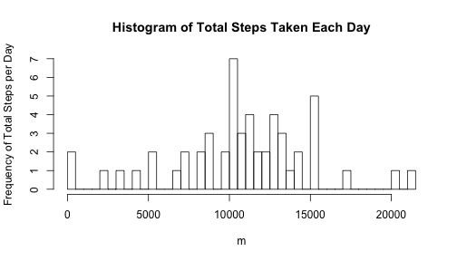

```r
m<-tapply(df$steps,df$date,sum)
hist(m,breaks=50,ylab="Frequency of Total Steps per Day",main="Histogram of Total Steps Taken Each Day")
```

#### Compute and Show the mean and median number of steps for each day

The date, mean value and median value are show for each day in the following table. The median value is to be zero for each day. The median is defined are the central location of the sorted data values. In the table all median values are zero. In order to investigate this further we calculated median values for several randomly chosen days and these showed consistent zero median results. Of the 15264 rows without missing data there are 4250 that contain non-zero steps values while 11014 contain zero steps values, giving a ratio of 72% of all steps entires as zero.  
We report the mean and median values over the total steps for all days following the table

```r
x<-tapply(df$steps,df$date,mean)
y<-tapply(df$steps,df$date,median)
sprintf("%s  %g  %g",rownames(x),x,y)
```

```
##  [1] "2012-10-02  0.4375  0"   "2012-10-03  39.4167  0"
##  [3] "2012-10-04  42.0694  0"  "2012-10-05  46.1597  0"
##  [5] "2012-10-06  53.5417  0"  "2012-10-07  38.2465  0"
##  [7] "2012-10-09  44.4826  0"  "2012-10-10  34.375  0"
##  [9] "2012-10-11  35.7778  0"  "2012-10-12  60.3542  0"
## [11] "2012-10-13  43.1458  0"  "2012-10-14  52.4236  0"
## [13] "2012-10-15  35.2049  0"  "2012-10-16  52.375  0"
## [15] "2012-10-17  46.7083  0"  "2012-10-18  34.9167  0"
## [17] "2012-10-19  41.0729  0"  "2012-10-20  36.0938  0"
## [19] "2012-10-21  30.6285  0"  "2012-10-22  46.7361  0"
## [21] "2012-10-23  30.9653  0"  "2012-10-24  29.0104  0"
## [23] "2012-10-25  8.65278  0"  "2012-10-26  23.5347  0"
## [25] "2012-10-27  35.1354  0"  "2012-10-28  39.7847  0"
## [27] "2012-10-29  17.4236  0"  "2012-10-30  34.0938  0"
## [29] "2012-10-31  53.5208  0"  "2012-11-02  36.8056  0"
## [31] "2012-11-03  36.7049  0"  "2012-11-05  36.2465  0"
## [33] "2012-11-06  28.9375  0"  "2012-11-07  44.7326  0"
## [35] "2012-11-08  11.1771  0"  "2012-11-11  43.7778  0"
## [37] "2012-11-12  37.3785  0"  "2012-11-13  25.4722  0"
## [39] "2012-11-15  0.142361  0" "2012-11-16  18.8924  0"
## [41] "2012-11-17  49.7882  0"  "2012-11-18  52.4653  0"
## [43] "2012-11-19  30.6979  0"  "2012-11-20  15.5278  0"
## [45] "2012-11-21  44.3993  0"  "2012-11-22  70.9271  0"
## [47] "2012-11-23  73.5903  0"  "2012-11-24  50.2708  0"
## [49] "2012-11-25  41.0903  0"  "2012-11-26  38.7569  0"
## [51] "2012-11-27  47.3819  0"  "2012-11-28  35.3576  0"
## [53] "2012-11-29  24.4688  0"
```

## The mean and median value over total steps for all days

```r
sprintf("mean and median value of sum of steps over all days %f   %f",mean(m),median(m))
```

```
## [1] "mean and median value of sum of steps over all days 10766.188679   10765.000000"
```

## What is the average daily activity pattern?

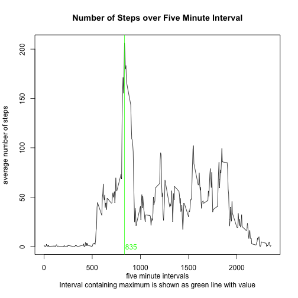

```r
x<-tapply(df$steps,df$interval,mean)
plot(y=x,,x=rownames(x),type="l",ylab="average number of steps",
          xlab="five minute intervals\nInterval containing maximum is shown as green line with value",main="Number of Steps over Five Minute Interval")
abline(v=xxx<-as.numeric(names(x[max(x)==x])),col="green")
text(x=(xxx+70),y=0,as.character(xxx),col="green")
```

```r
sprintf("Maximum Value is %g",as.numeric(x[max(x)==x]))
```

```
## [1] "Maximum Value is 206.17"
```

## Imputing missing values

Calculatge the total number of missing values in the data

```r
sprintf("total number of missing values in data set is %d",sum(is.na(dfNA)))
```

```
## [1] "total number of missing values in data set is 2304"
```

We calculate imputed values by using the average (mean) value for each of the five minute intervals data frame df contains step values with NA rows removed, data frame dfNA contain all steps data including NA values. The strategy used to impute missing values is to replace these with the simple mean for that interval calculated over all days.

```r
q<-tapply(dfNA$steps,dfNA$interval,mean,na.rm=TRUE)
b<-ifelse(is.na(dfNA$steps), q,dfNA$steps)
dfN<-data.frame(b,dfNA$date,dfNA$interval)
names(dfN)<-names(dfNA)
```

### Does imputing missing values in this way change the value of the mean and median?

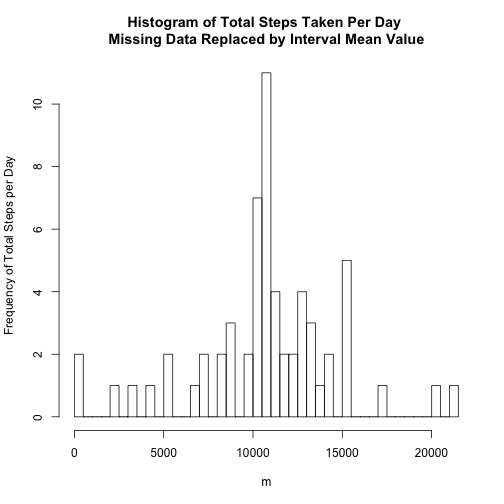

```r
m<-tapply(dfN$steps,dfN$date,sum)
hist(m,breaks=50,ylab="Frequency of Total Steps per Day",
     main="Histogram of Total Steps Taken Per Day \nMissing Data Replaced by Interval Mean Value")
```

### Calculate mean and median for dataset with mean value replacing missing values

The values in the following table are date, mean and median for each day. Do the values differ from the those calculated in the first part of the asisgnment and what is the impact on the total daily number of steps? The answer to both questions is replacing missing values with values choosen from this imputing strategy seem not to significantly change the results. The histogram shapes appear similar as well. Our table of mean and median values by day does show some changes both averge and median values in various places.

```r
x<-tapply(dfN$steps,dfN$date,mean)
y<-tapply(dfN$steps,dfN$date,median)
sprintf("%s %f  %f",rownames(x),x,y)
```

```
##  [1] "2012-10-01 37.382600  34.113208" "2012-10-02 0.437500  0.000000"
##  [3] "2012-10-03 39.416667  0.000000"  "2012-10-04 42.069444  0.000000"
##  [5] "2012-10-05 46.159722  0.000000"  "2012-10-06 53.541667  0.000000"
##  [7] "2012-10-07 38.246528  0.000000"  "2012-10-08 37.382600  34.113208"
##  [9] "2012-10-09 44.482639  0.000000"  "2012-10-10 34.375000  0.000000"
## [11] "2012-10-11 35.777778  0.000000"  "2012-10-12 60.354167  0.000000"
## [13] "2012-10-13 43.145833  0.000000"  "2012-10-14 52.423611  0.000000"
## [15] "2012-10-15 35.204861  0.000000"  "2012-10-16 52.375000  0.000000"
## [17] "2012-10-17 46.708333  0.000000"  "2012-10-18 34.916667  0.000000"
## [19] "2012-10-19 41.072917  0.000000"  "2012-10-20 36.093750  0.000000"
## [21] "2012-10-21 30.628472  0.000000"  "2012-10-22 46.736111  0.000000"
## [23] "2012-10-23 30.965278  0.000000"  "2012-10-24 29.010417  0.000000"
## [25] "2012-10-25 8.652778  0.000000"   "2012-10-26 23.534722  0.000000"
## [27] "2012-10-27 35.135417  0.000000"  "2012-10-28 39.784722  0.000000"
## [29] "2012-10-29 17.423611  0.000000"  "2012-10-30 34.093750  0.000000"
```

[output cut: 16 more lines]

## The mean and median value over total steps for all days

```r
sprintf("mean and median value of sum of steps over all days (with imputed values) %f   %f",mean(m),median(m))
```

```
## [1] "mean and median value of sum of steps over all days (with imputed values) 10766.188679   10766.188679"
```

## Are there differences in activity between weekdays and weekends?

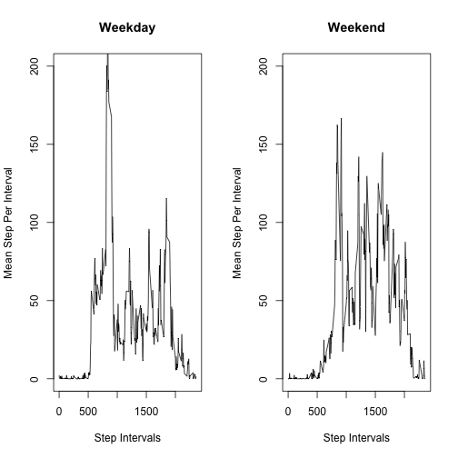

```r
days<-weekdays(as.Date(dfN$date))
dfN["weekend"]<-factor(ifelse( ( days=="Saturday" | days=="Sunday" ),"weekend","weekday"))
d<-with(dfN, tapply(steps,list(interval,weekend),mean))
par(mfrow=c(1,2))
plot(y=d[,1],x=rownames(d), type="l",xlim=c(0,max(dfN$interval)),ylim=c(0,200), main="Weekday",xlab="Step Intervals",ylab="Mean Step Per Interval")
plot(y=d[,2],x=rownames(d), type="l",xlim=c(0,max(dfN$interval)),ylim=c(0,200), main="Weekend",xlab="Step Intervals",ylab="Mean Step Per Interval")
```